# Chance’s Second Thesis Chapter: Understand Thermal Niche from Consumption TPCs

**Question:** Is there thermal niche overlap or complementary in consumption among the predatory crabs of the Gulf of Maine?

**Hypothesis:** There is thermal niche complementary between the crab predators.

**Null Hypothesis:** There is thermal niche overlap between the crab predators.

**Predictions:**

**Experimental Design:**

2 Systems (2 possible temperatures at a time), 5 temperature regimes (minimum to map out a TPC), 3 species, 6 repetitions. We can only fit 18 individuals in each system.

6 reps * 3 species * 5 temperature regimes * 2 temporal blocks = 180 crabs

## Data Processing

#### Cleaning up data for use

We need to clean up the data first to use it. What I did…

- Created a new value for each crab feeding point (Food in - Food out to get total eaten). Then calculated proportion eaten by taking the amount eaten and diving it by the body weight of the crab.
- I pushed all those who did not eat to 0 (noted who didn’t eat via bite marks, but didn’t explicitly write 0 still).
- Removed feeding points where individuals ate everything and those who died.
- Removed those who molted during the experiment
- Removed the mackerel and mussel feeding (since they were a one off feeding and did not measure well)

## Data Exploration

### Basic information on the dataset (Post Data Modifications)

Sample size for each species, trial

|  | 18 | 20 | 22 | 24 | 26 |
| --- | --- | --- | --- | --- | --- |
| Carcinus | 12 | 12 | 12 | 12 | 12 |
| Hemigrapsus | 12 | 12 | 12 | 12 | 12 |
| Irroratus | 12 | 12 | 12 | 12 | 12 |

Sample size for each feeding trial

|  | 18 | 20 | 22 | 24 | 26 |
| --- | --- | --- | --- | --- | --- |
| CI | 90 | 106 | 82 | 104 | 91 |
| CM | 85 | 95 | 73 | 92 | 94 |
| HS | 83 | 90 | 80 | 96 | 67 |

Average Carapace Length for each species, trial

|  | 18 | 20 | 22 | 24 | 26 |
| --- | --- | --- | --- | --- | --- |
| CI | 105.03333 | 103.61321 | 110.10976 | 101.27885 | 108.53846 |
| CM | 64.64706 | 67.97895 | 65.60274 | 64.21739 | 65.72340 |
| HS | 19.97590 | 20.90000 | 22.01250 | 19.71875 | 21.29851 |

### Death Count Among Species and Trial (data includes those who died (prvious feed points before death))

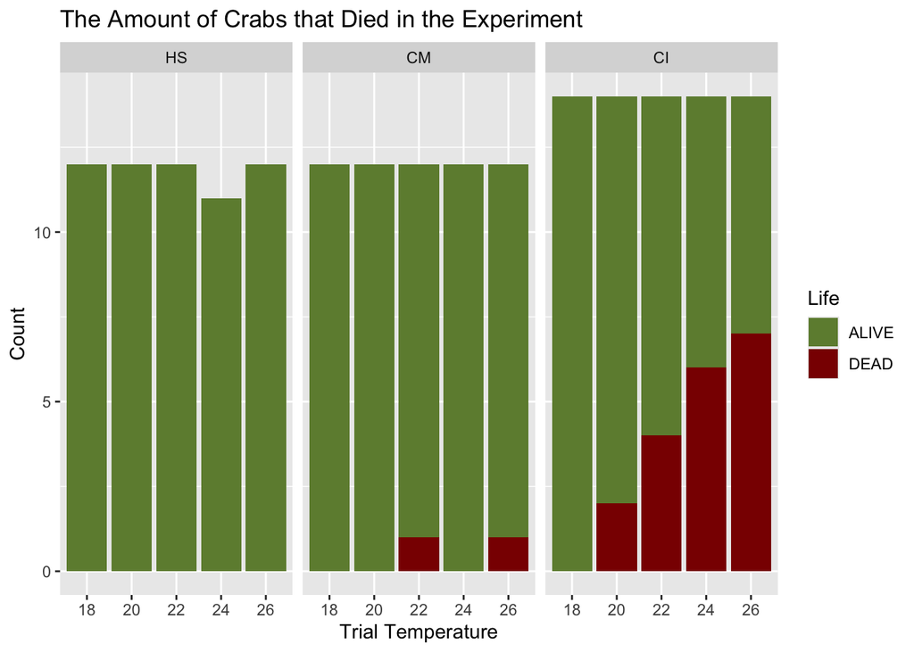

*Cancer irroratus* have the highest death count among all 3 species with *Hemigrapsus* having none and *Carcinus meanus* only having two death counts. Across trials with *Cancer irroratus*, the higher the trial temperature the more deaths there are as well.

#### Amount of who did not eat by species and trial

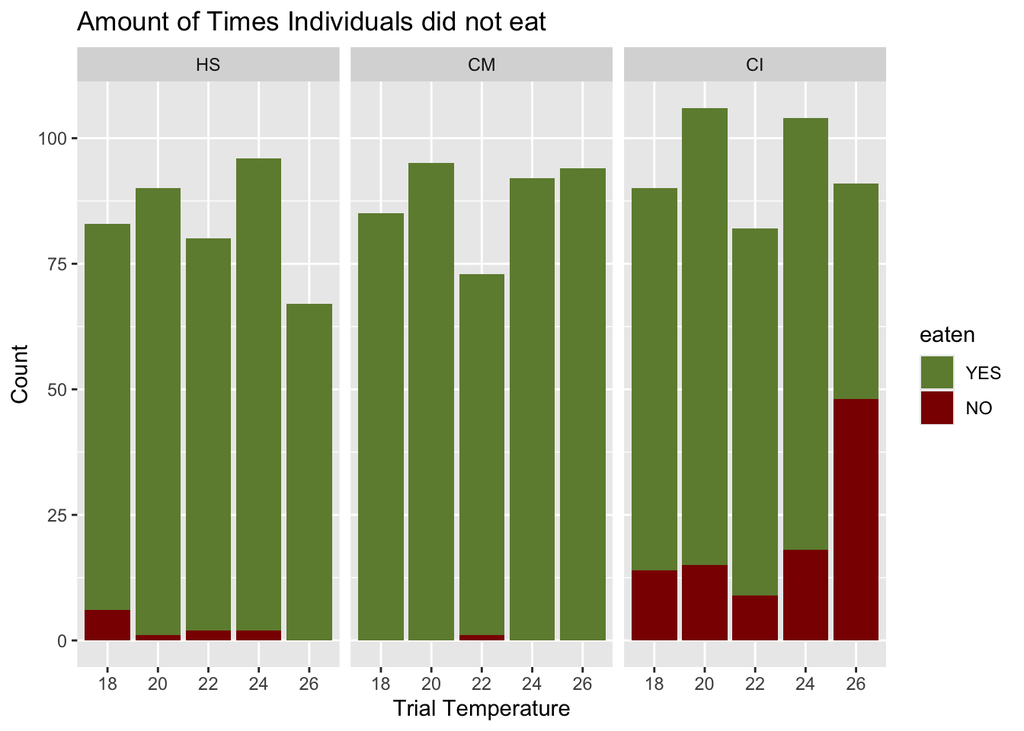

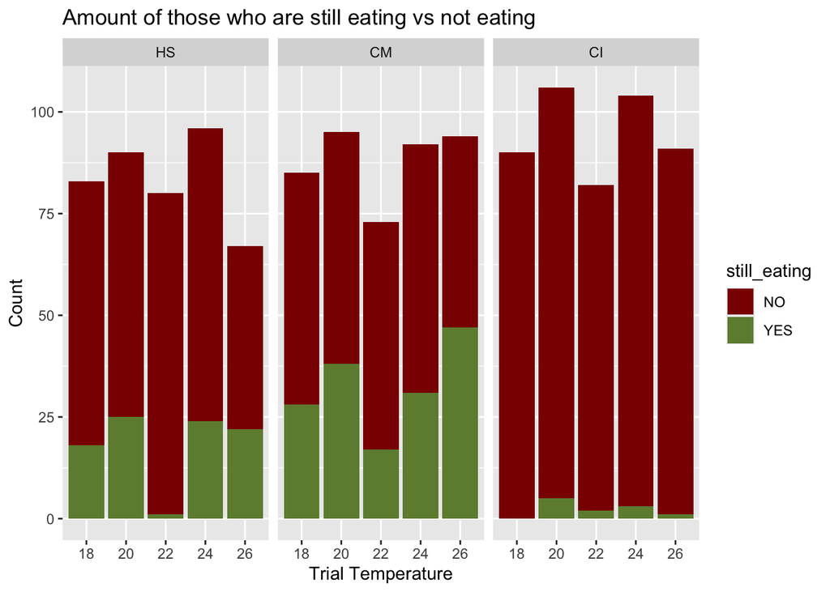

## Outlier Search

```
##  contrast                          estimate   SE df t.ratio p.value
##  Trial18 Period1 - Trial20 Period1   -0.537 41.6 50  -0.013  1.0000
##  Trial18 Period1 - Trial22 Period1  -26.623 41.6 50  -0.640  0.9997
##  Trial18 Period1 - Trial24 Period1    2.860 41.6 50   0.069  1.0000
##  Trial18 Period1 - Trial26 Period1  -63.087 41.6 50  -1.516  0.8791
##  Trial18 Period1 - Trial18 Period2  -54.085 41.6 50  -1.300  0.9490
##  Trial18 Period1 - Trial20 Period2  -44.397 41.6 50  -1.067  0.9857
##  Trial18 Period1 - Trial22 Period2  -59.192 41.6 50  -1.423  0.9141
##  Trial18 Period1 - Trial24 Period2   -8.643 41.6 50  -0.208  1.0000
##  Trial18 Period1 - Trial26 Period2  -35.408 41.6 50  -0.851  0.9972
##  Trial20 Period1 - Trial22 Period1  -26.087 41.6 50  -0.627  0.9998
##  Trial20 Period1 - Trial24 Period1    3.397 41.6 50   0.082  1.0000
##  Trial20 Period1 - Trial26 Period1  -62.550 41.6 50  -1.504  0.8844
##  Trial20 Period1 - Trial18 Period2  -53.548 41.6 50  -1.287  0.9520
##  Trial20 Period1 - Trial20 Period2  -43.860 41.6 50  -1.054  0.9869
##  Trial20 Period1 - Trial22 Period2  -58.655 41.6 50  -1.410  0.9184
##  Trial20 Period1 - Trial24 Period2   -8.107 41.6 50  -0.195  1.0000
##  Trial20 Period1 - Trial26 Period2  -34.872 41.6 50  -0.838  0.9975
##  Trial22 Period1 - Trial24 Period1   29.483 41.6 50   0.709  0.9993
##  Trial22 Period1 - Trial26 Period1  -36.463 41.6 50  -0.877  0.9965
##  Trial22 Period1 - Trial18 Period2  -27.462 41.6 50  -0.660  0.9996
##  Trial22 Period1 - Trial20 Period2  -17.773 41.6 50  -0.427  1.0000
##  Trial22 Period1 - Trial22 Period2  -32.568 41.6 50  -0.783  0.9985
##  Trial22 Period1 - Trial24 Period2   17.980 41.6 50   0.432  1.0000
##  Trial22 Period1 - Trial26 Period2   -8.785 41.6 50  -0.211  1.0000
##  Trial24 Period1 - Trial26 Period1  -65.947 41.6 50  -1.585  0.8488
##  Trial24 Period1 - Trial18 Period2  -56.945 41.6 50  -1.369  0.9310
##  Trial24 Period1 - Trial20 Period2  -47.257 41.6 50  -1.136  0.9783
##  Trial24 Period1 - Trial22 Period2  -62.052 41.6 50  -1.492  0.8891
##  Trial24 Period1 - Trial24 Period2  -11.503 41.6 50  -0.277  1.0000
##  Trial24 Period1 - Trial26 Period2  -38.268 41.6 50  -0.920  0.9951
##  Trial26 Period1 - Trial18 Period2    9.002 41.6 50   0.216  1.0000
##  Trial26 Period1 - Trial20 Period2   18.690 41.6 50   0.449  1.0000
##  Trial26 Period1 - Trial22 Period2    3.895 41.6 50   0.094  1.0000
##  Trial26 Period1 - Trial24 Period2   54.443 41.6 50   1.309  0.9470
##  Trial26 Period1 - Trial26 Period2   27.678 41.6 50   0.665  0.9996
##  Trial18 Period2 - Trial20 Period2    9.688 41.6 50   0.233  1.0000
##  Trial18 Period2 - Trial22 Period2   -5.107 41.6 50  -0.123  1.0000
##  Trial18 Period2 - Trial24 Period2   45.442 41.6 50   1.092  0.9833
##  Trial18 Period2 - Trial26 Period2   18.677 41.6 50   0.449  1.0000
##  Trial20 Period2 - Trial22 Period2  -14.795 41.6 50  -0.356  1.0000
##  Trial20 Period2 - Trial24 Period2   35.753 41.6 50   0.859  0.9970
##  Trial20 Period2 - Trial26 Period2    8.988 41.6 50   0.216  1.0000
##  Trial22 Period2 - Trial24 Period2   50.548 41.6 50   1.215  0.9664
##  Trial22 Period2 - Trial26 Period2   23.783 41.6 50   0.572  0.9999
##  Trial24 Period2 - Trial26 Period2  -26.765 41.6 50  -0.643  0.9997
##
## P value adjustment: tukey method for comparing a family of 10 estimates
```

```
##  contrast                          estimate   SE df t.ratio p.value
##  Trial18 Period1 - Trial20 Period1  -25.323 17.9 50  -1.411  0.9181
##  Trial18 Period1 - Trial22 Period1  -18.163 17.9 50  -1.012  0.9902
##  Trial18 Period1 - Trial24 Period1  -16.123 17.9 50  -0.898  0.9959
##  Trial18 Period1 - Trial26 Period1    3.402 17.9 50   0.190  1.0000
##  Trial18 Period1 - Trial18 Period2   -5.240 17.9 50  -0.292  1.0000
##  Trial18 Period1 - Trial20 Period2  -14.175 17.9 50  -0.790  0.9984
##  Trial18 Period1 - Trial22 Period2    7.033 17.9 50   0.392  1.0000
##  Trial18 Period1 - Trial24 Period2   14.662 17.9 50   0.817  0.9980
##  Trial18 Period1 - Trial26 Period2   -4.493 17.9 50  -0.250  1.0000
##  Trial20 Period1 - Trial22 Period1    7.160 17.9 50   0.399  1.0000
##  Trial20 Period1 - Trial24 Period1    9.200 17.9 50   0.513  1.0000
##  Trial20 Period1 - Trial26 Period1   28.725 17.9 50   1.600  0.8416
##  Trial20 Period1 - Trial18 Period2   20.083 17.9 50   1.119  0.9804
##  Trial20 Period1 - Trial20 Period2   11.148 17.9 50   0.621  0.9998
##  Trial20 Period1 - Trial22 Period2   32.357 17.9 50   1.803  0.7303
##  Trial20 Period1 - Trial24 Period2   39.985 17.9 50   2.228  0.4524
##  Trial20 Period1 - Trial26 Period2   20.830 17.9 50   1.161  0.9750
##  Trial22 Period1 - Trial24 Period1    2.040 17.9 50   0.114  1.0000
##  Trial22 Period1 - Trial26 Period1   21.565 17.9 50   1.201  0.9687
##  Trial22 Period1 - Trial18 Period2   12.923 17.9 50   0.720  0.9992
##  Trial22 Period1 - Trial20 Period2    3.988 17.9 50   0.222  1.0000
##  Trial22 Period1 - Trial22 Period2   25.197 17.9 50   1.404  0.9203
##  Trial22 Period1 - Trial24 Period2   32.825 17.9 50   1.829  0.7142
##  Trial22 Period1 - Trial26 Period2   13.670 17.9 50   0.762  0.9988
##  Trial24 Period1 - Trial26 Period1   19.525 17.9 50   1.088  0.9838
##  Trial24 Period1 - Trial18 Period2   10.883 17.9 50   0.606  0.9998
##  Trial24 Period1 - Trial20 Period2    1.948 17.9 50   0.109  1.0000
##  Trial24 Period1 - Trial22 Period2   23.157 17.9 50   1.290  0.9513
##  Trial24 Period1 - Trial24 Period2   30.785 17.9 50   1.715  0.7817
##  Trial24 Period1 - Trial26 Period2   11.630 17.9 50   0.648  0.9997
##  Trial26 Period1 - Trial18 Period2   -8.642 17.9 50  -0.481  1.0000
##  Trial26 Period1 - Trial20 Period2  -17.577 17.9 50  -0.979  0.9922
##  Trial26 Period1 - Trial22 Period2    3.632 17.9 50   0.202  1.0000
##  Trial26 Period1 - Trial24 Period2   11.260 17.9 50   0.627  0.9998
##  Trial26 Period1 - Trial26 Period2   -7.895 17.9 50  -0.440  1.0000
##  Trial18 Period2 - Trial20 Period2   -8.935 17.9 50  -0.498  1.0000
##  Trial18 Period2 - Trial22 Period2   12.273 17.9 50   0.684  0.9995
##  Trial18 Period2 - Trial24 Period2   19.902 17.9 50   1.109  0.9815
##  Trial18 Period2 - Trial26 Period2    0.747 17.9 50   0.042  1.0000
##  Trial20 Period2 - Trial22 Period2   21.208 17.9 50   1.182  0.9719
##  Trial20 Period2 - Trial24 Period2   28.837 17.9 50   1.607  0.8386
##  Trial20 Period2 - Trial26 Period2    9.682 17.9 50   0.539  0.9999
##  Trial22 Period2 - Trial24 Period2    7.628 17.9 50   0.425  1.0000
##  Trial22 Period2 - Trial26 Period2  -11.527 17.9 50  -0.642  0.9997
##  Trial24 Period2 - Trial26 Period2  -19.155 17.9 50  -1.067  0.9857
##
## P value adjustment: tukey method for comparing a family of 10 estimates
```

```
##  contrast                          estimate    SE df t.ratio p.value
##  Trial18 Period1 - Trial20 Period1 -0.10333 0.872 50  -0.119  1.0000
##  Trial18 Period1 - Trial22 Period1 -0.57833 0.872 50  -0.663  0.9996
##  Trial18 Period1 - Trial24 Period1 -0.10667 0.872 50  -0.122  1.0000
##  Trial18 Period1 - Trial26 Period1  1.20833 0.872 50   1.386  0.9260
##  Trial18 Period1 - Trial18 Period2 -1.04500 0.872 50  -1.198  0.9692
##  Trial18 Period1 - Trial20 Period2  0.52667 0.872 50   0.604  0.9998
##  Trial18 Period1 - Trial22 Period2 -0.66667 0.872 50  -0.765  0.9988
##  Trial18 Period1 - Trial24 Period2  1.65833 0.872 50   1.902  0.6678
##  Trial18 Period1 - Trial26 Period2 -1.92333 0.872 50  -2.206  0.4666
##  Trial20 Period1 - Trial22 Period1 -0.47500 0.872 50  -0.545  0.9999
##  Trial20 Period1 - Trial24 Period1 -0.00333 0.872 50  -0.004  1.0000
##  Trial20 Period1 - Trial26 Period1  1.31167 0.872 50   1.504  0.8841
##  Trial20 Period1 - Trial18 Period2 -0.94167 0.872 50  -1.080  0.9845
##  Trial20 Period1 - Trial20 Period2  0.63000 0.872 50   0.722  0.9992
##  Trial20 Period1 - Trial22 Period2 -0.56333 0.872 50  -0.646  0.9997
##  Trial20 Period1 - Trial24 Period2  1.76167 0.872 50   2.020  0.5895
##  Trial20 Period1 - Trial26 Period2 -1.82000 0.872 50  -2.087  0.5447
##  Trial22 Period1 - Trial24 Period1  0.47167 0.872 50   0.541  0.9999
##  Trial22 Period1 - Trial26 Period1  1.78667 0.872 50   2.049  0.5703
##  Trial22 Period1 - Trial18 Period2 -0.46667 0.872 50  -0.535  0.9999
##  Trial22 Period1 - Trial20 Period2  1.10500 0.872 50   1.267  0.9564
##  Trial22 Period1 - Trial22 Period2 -0.08833 0.872 50  -0.101  1.0000
##  Trial22 Period1 - Trial24 Period2  2.23667 0.872 50   2.565  0.2611
##  Trial22 Period1 - Trial26 Period2 -1.34500 0.872 50  -1.542  0.8682
##  Trial24 Period1 - Trial26 Period1  1.31500 0.872 50   1.508  0.8826
##  Trial24 Period1 - Trial18 Period2 -0.93833 0.872 50  -1.076  0.9849
##  Trial24 Period1 - Trial20 Period2  0.63333 0.872 50   0.726  0.9992
##  Trial24 Period1 - Trial22 Period2 -0.56000 0.872 50  -0.642  0.9997
##  Trial24 Period1 - Trial24 Period2  1.76500 0.872 50   2.024  0.5869
##  Trial24 Period1 - Trial26 Period2 -1.81667 0.872 50  -2.083  0.5473
##  Trial26 Period1 - Trial18 Period2 -2.25333 0.872 50  -2.584  0.2521
##  Trial26 Period1 - Trial20 Period2 -0.68167 0.872 50  -0.782  0.9986
##  Trial26 Period1 - Trial22 Period2 -1.87500 0.872 50  -2.150  0.5028
##  Trial26 Period1 - Trial24 Period2  0.45000 0.872 50   0.516  1.0000
##  Trial26 Period1 - Trial26 Period2 -3.13167 0.872 50  -3.591  0.0237
##  Trial18 Period2 - Trial20 Period2  1.57167 0.872 50   1.802  0.7305
##  Trial18 Period2 - Trial22 Period2  0.37833 0.872 50   0.434  1.0000
##  Trial18 Period2 - Trial24 Period2  2.70333 0.872 50   3.100  0.0840
##  Trial18 Period2 - Trial26 Period2 -0.87833 0.872 50  -1.007  0.9905
##  Trial20 Period2 - Trial22 Period2 -1.19333 0.872 50  -1.368  0.9311
##  Trial20 Period2 - Trial24 Period2  1.13167 0.872 50   1.298  0.9496
##  Trial20 Period2 - Trial26 Period2 -2.45000 0.872 50  -2.810  0.1612
##  Trial22 Period2 - Trial24 Period2  2.32500 0.872 50   2.666  0.2156
##  Trial22 Period2 - Trial26 Period2 -1.25667 0.872 50  -1.441  0.9079
##  Trial24 Period2 - Trial26 Period2 -3.58167 0.872 50  -4.107  0.0053
##
## P value adjustment: tukey method for comparing a family of 10 estimates
```

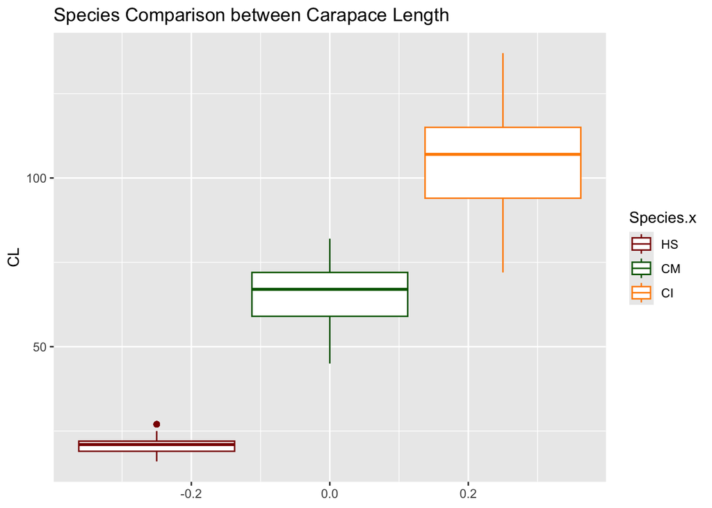

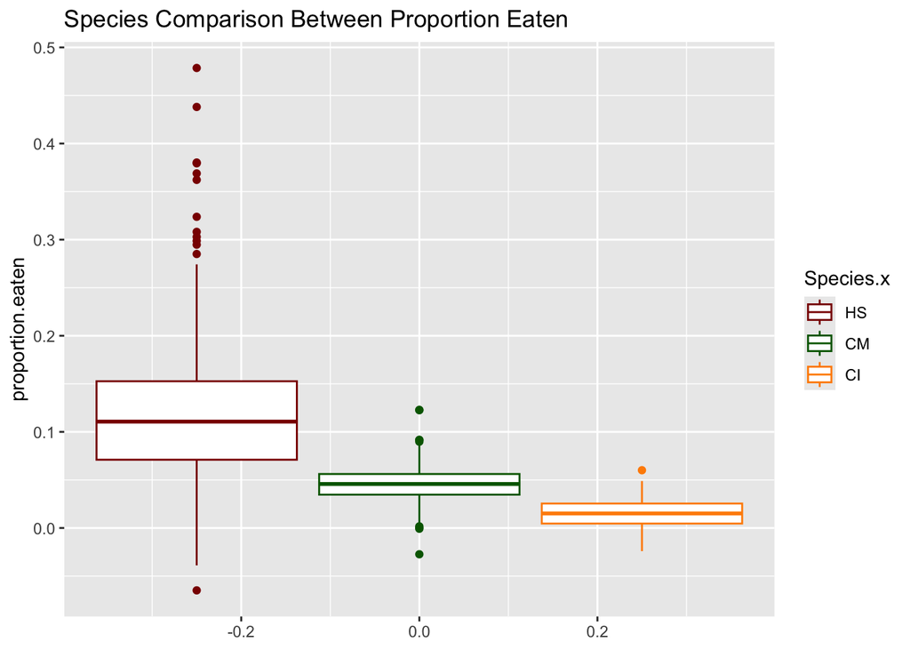

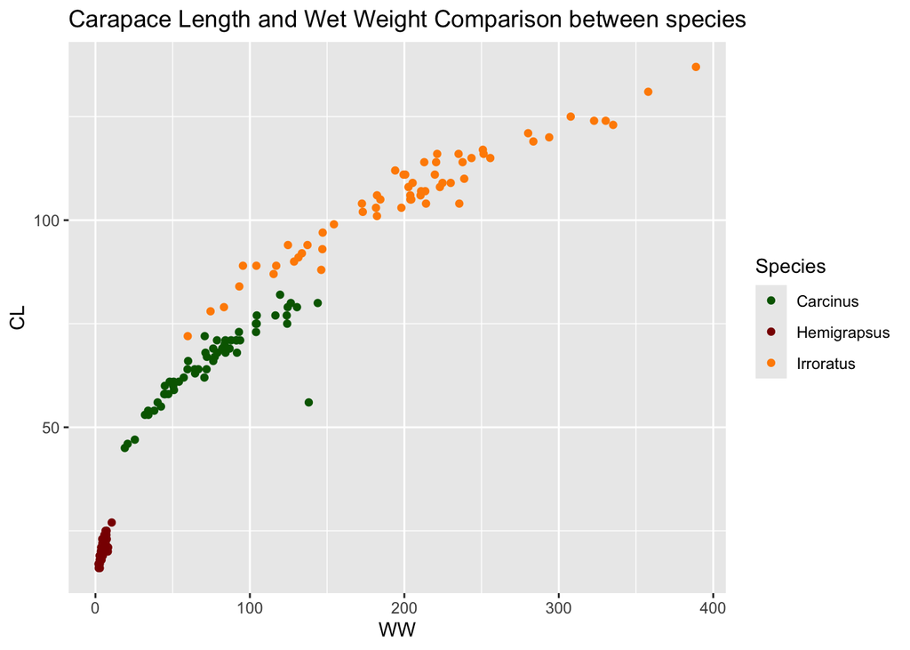

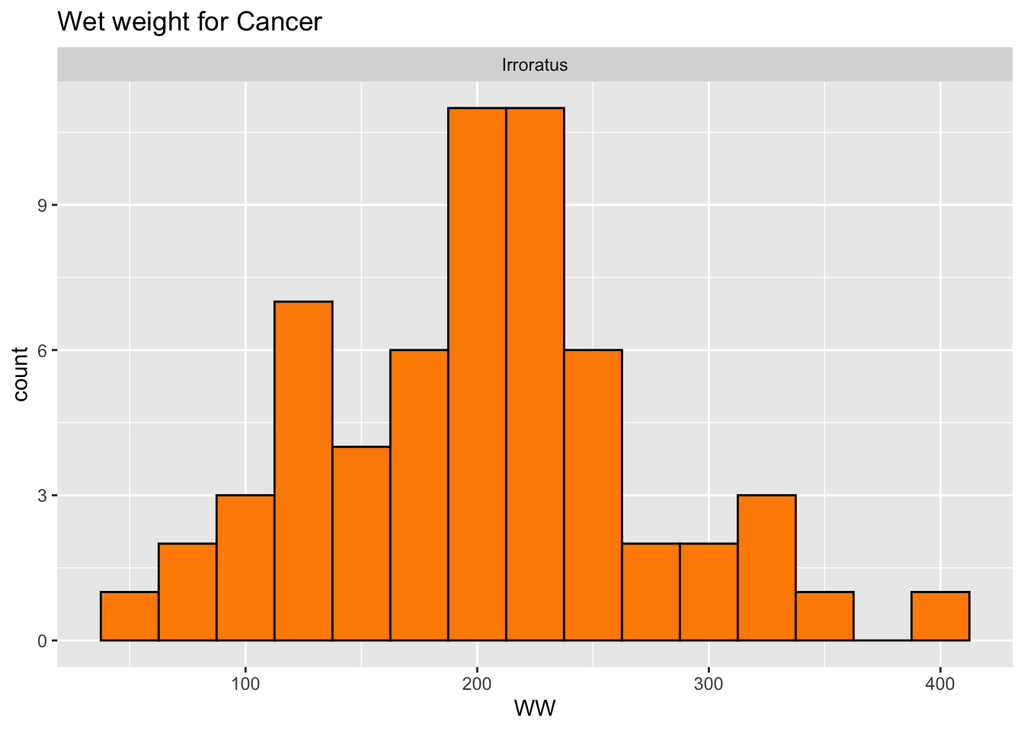

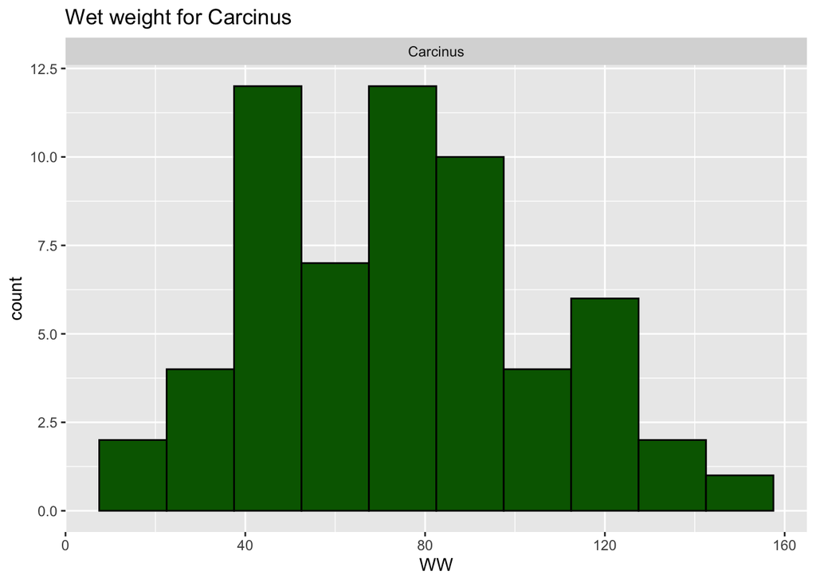

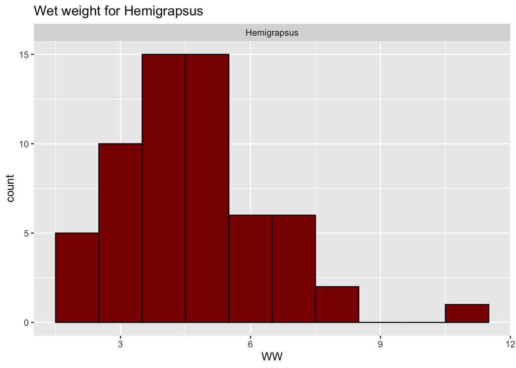

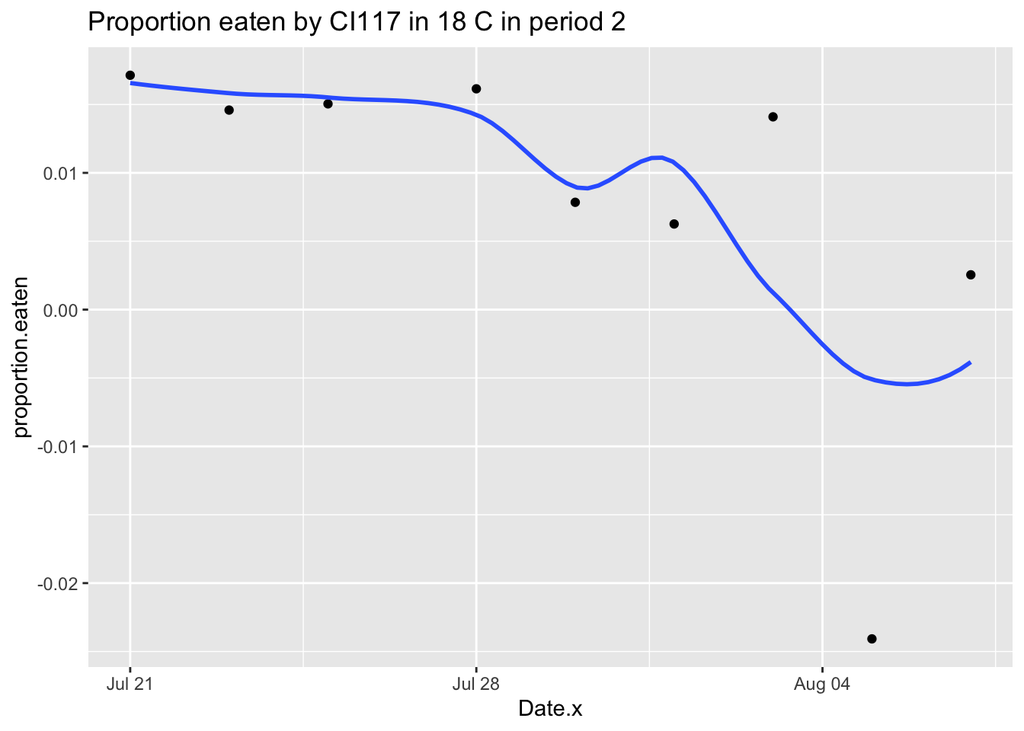

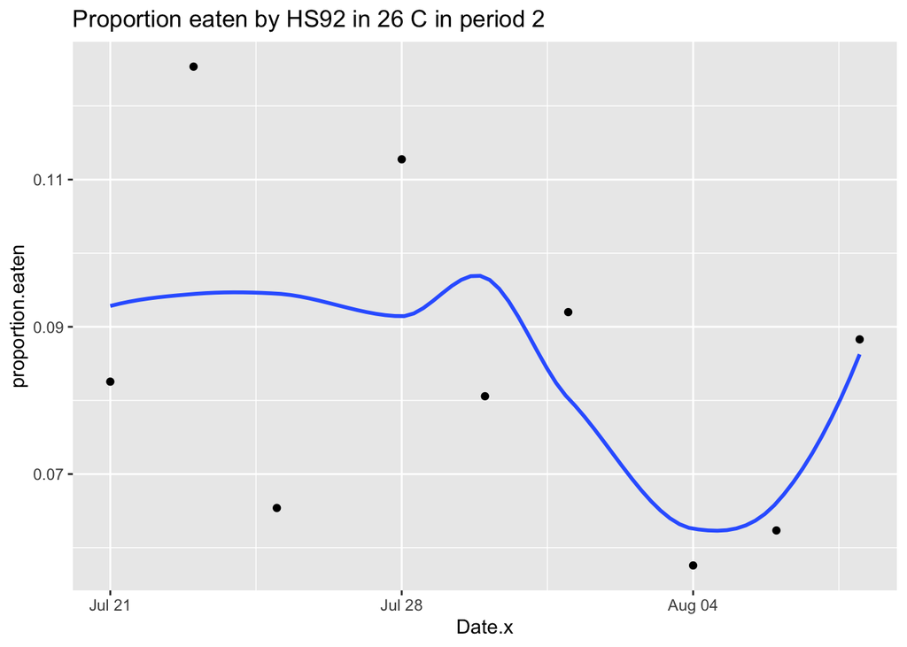

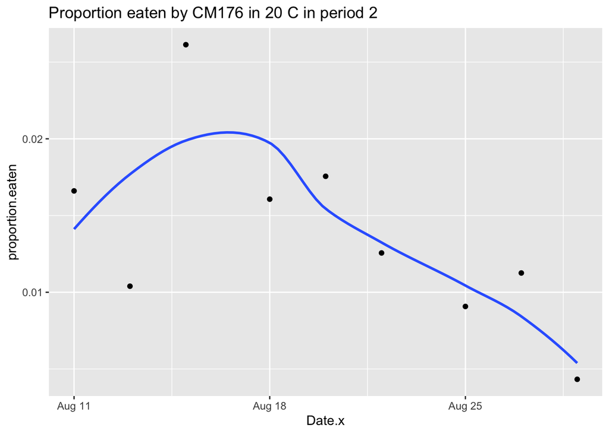

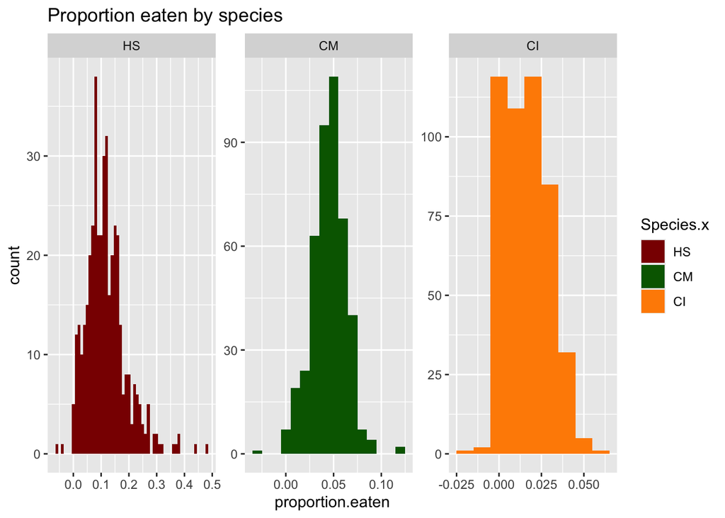

- *Cancer irroratus* are larger than the other two species followed by *Carcinus meanus* then the smallest as *Hemigrapsus*.
- The pattern is opposite when it comes to the amount they’ve eaten proportionally. So *Hemigrapsus* eats the most and *Cancer irroratus* eats the least.

There is a nice relationship between carapace length and wet weight. However, there was an outlier. I have thrown it out since it’s the ONLY one so far off, but I have checked and data was entered correctly.

For each species on wet weight normality:

-Cancer: Pretty normal

-Green crab: Normal with some outliers

-Hemi: Normal with some outliers

It seems like Cancer crabs have a left leaning normality curve. Green crabs have a normal spread. Hemigrapsus have a left leaning curve as well. Unsure if this is even a valid graph because it’s kind of what we expected if Cancer crabs are all tanking 0’s due to it being too hot.

The only differences between size of trial and species is Hemigrapsus for Trial 26 between period 1 and 2 by about 3 grams of differnece. The other difference is for Trial 24 and 26 in period 2.

## Relationships

#### Food Effects

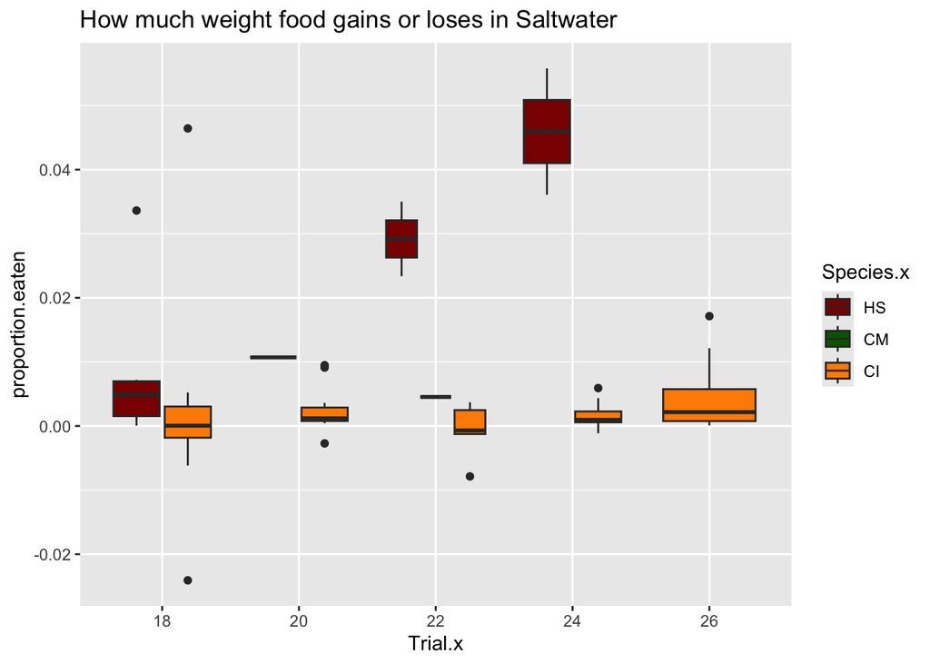

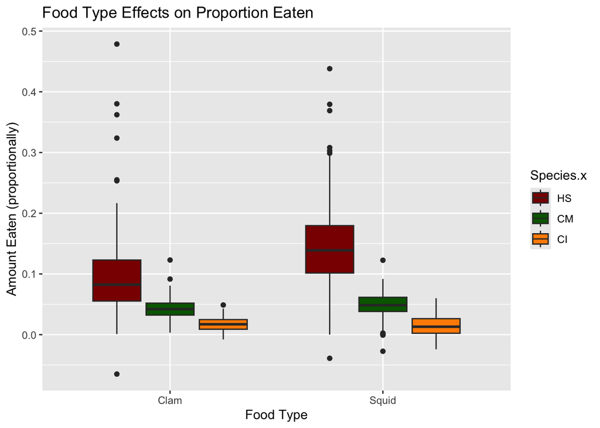

After running a t-test on these, it seems like green crabs and Hemigrapsus have a slight preference for squid rather than clam. Meanwhile Cancer crabs have no preference between the food types.

### Size effect on Consumption

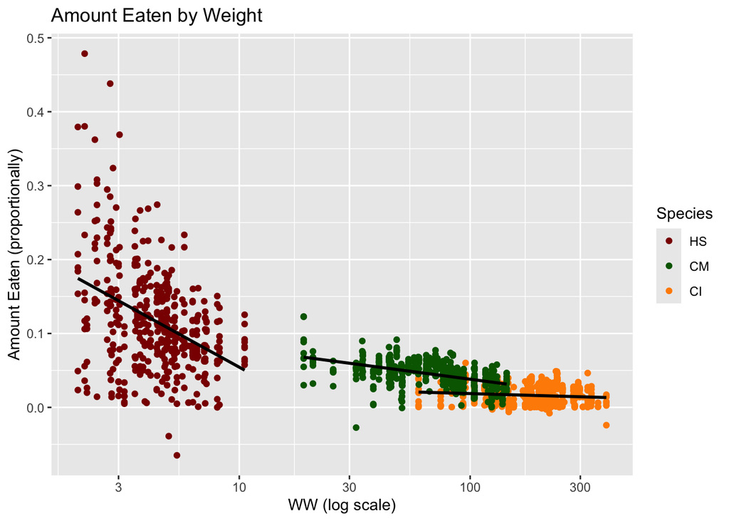

### Schedule

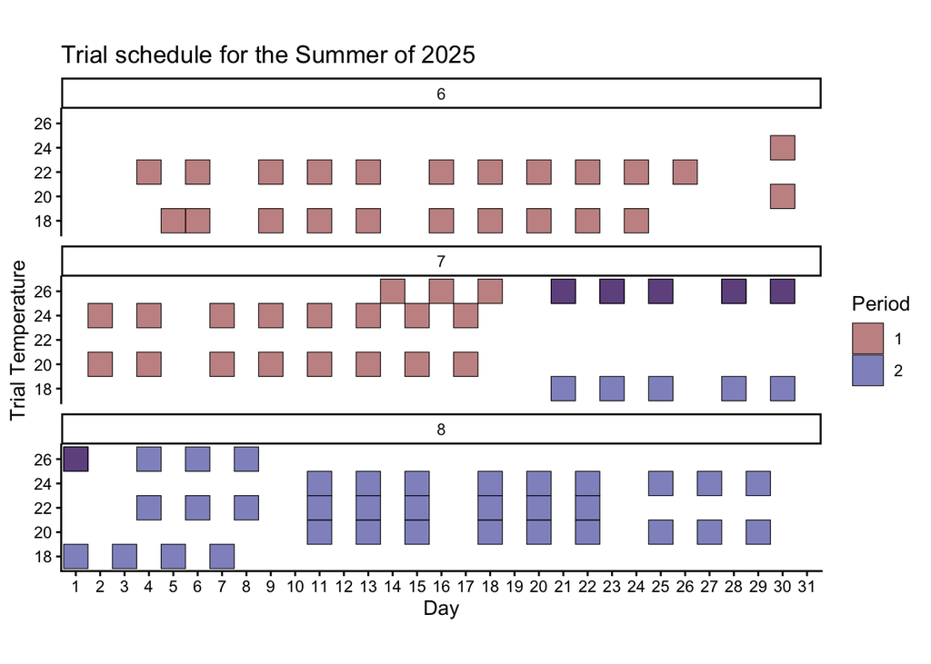

Before we can analyze the proportion eaten, we have to understand if the acclimation worked… To do this, we’ll bin each week by each other and calculate averages to compare.

### Checking for Acclimation

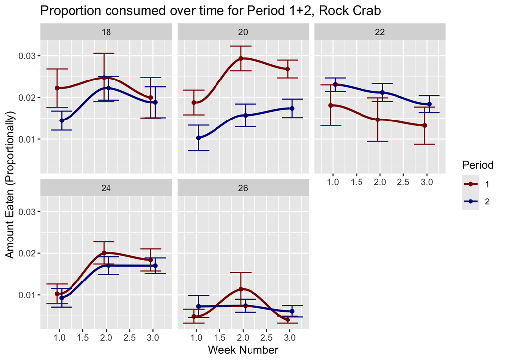

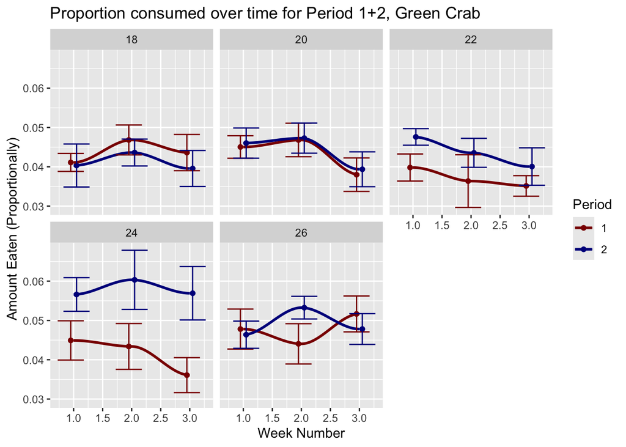

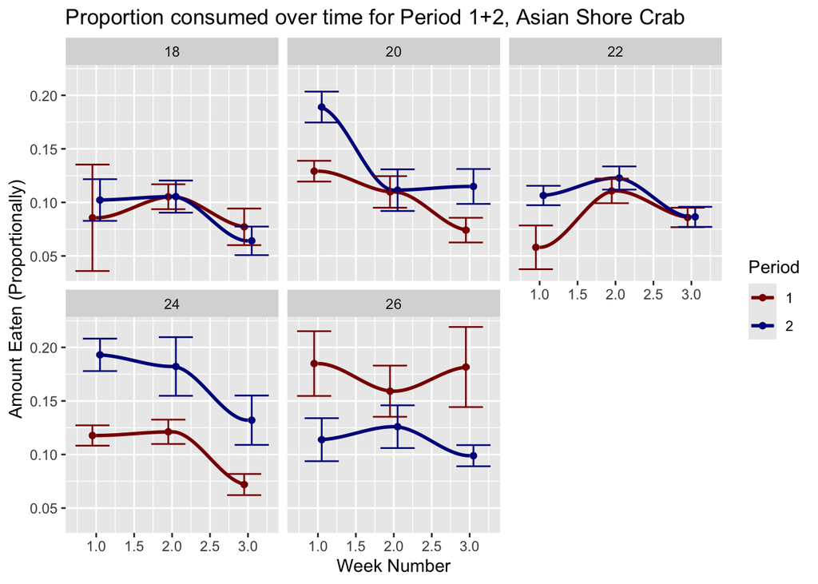

### Looking at the proportion eaten for each trial for each individual species (CI, CM, and HS)

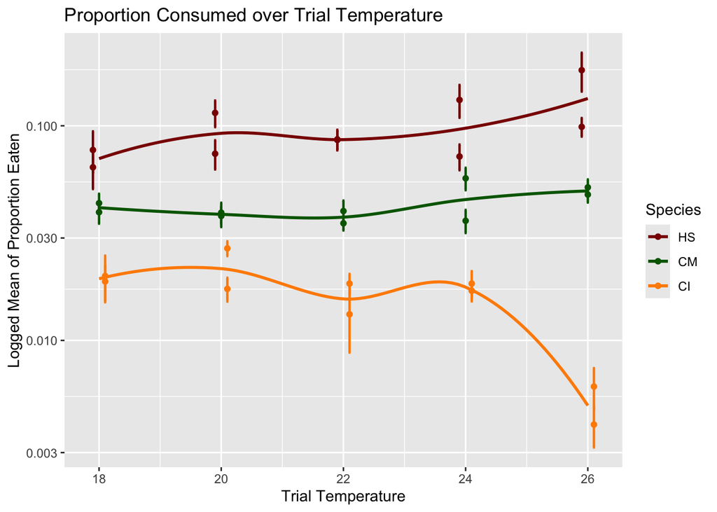

### Regraphing Hemi and Carcinus without those who didn’t eat (prediction of molt)

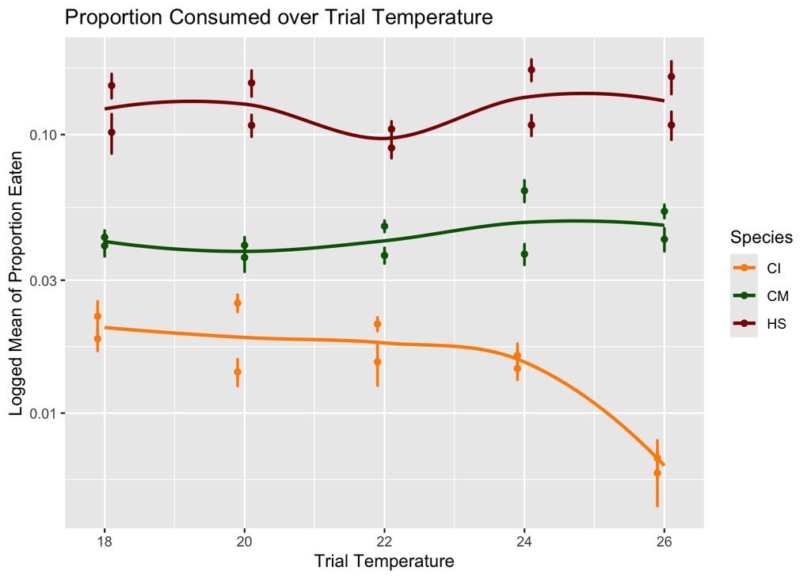

### Graphing the Husbandry Logs

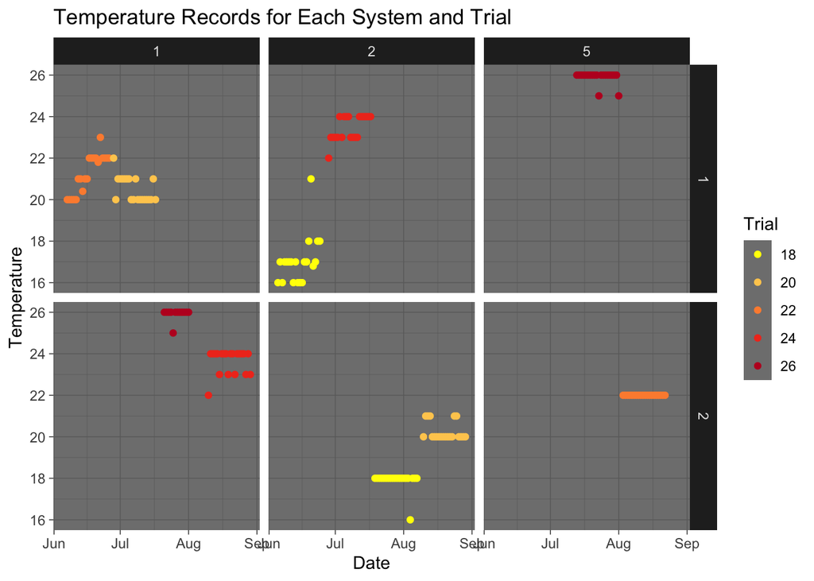

### Graphing Crab mass before and after the experiment

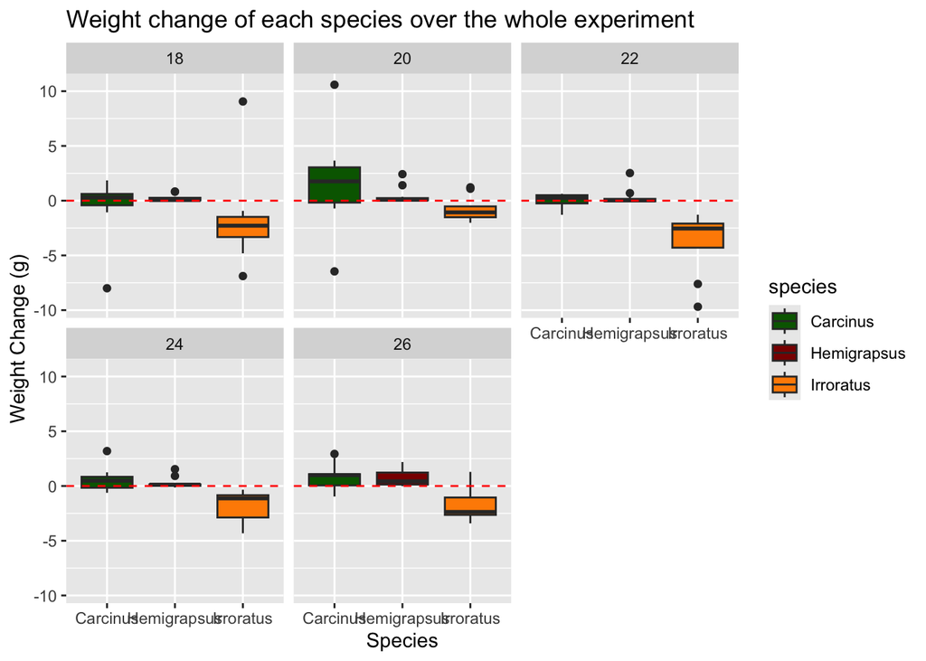